# Statistics Lab - Key

# Part 1

### 1.1

Load the packages needed in this lab. Then, read in the CalEnviroScreen data and assign it to the “ces” object. You can find the data at https://daseh.org/data/CalEnviroScreen_data.csv

```r
library(tidyverse)
library(broom)
```

```r
ces <- read_csv("https://daseh.org/data/CalEnviroScreen_data.csv")
```

### 1.2

Compute the correlation (with `cor`) between the `HousingBurden` and `LowBirthWeight` variables.

- Select columns or extract these columns as vectors.
- Use the `cor` function on this object.
- Add the `use = "complete.obs"` argument.

`HousingBurden`: Percentage of housing-burdened low-income households. Households are considered cost-burdened when they spend more than 30% of their income on rent, mortgage payments, and other housing costs

`LowBirthWeight`: Percentage of births that are low birth weight.

```r
ces_sub <-
  ces |>
  select(HousingBurden, LowBirthWeight)

cor(ces_sub, use = "complete.obs")
```

```
##                HousingBurden LowBirthWeight
## HousingBurden      1.0000000      0.2841148
## LowBirthWeight     0.2841148      1.0000000
```

```r
# or

ces_housing <- ces |> pull(HousingBurden)
ces_bw <- ces |> pull(LowBirthWeight)
cor(ces_housing, ces_bw, use = "complete.obs")
```

```
## [1] 0.2841148
```

### 1.3

Change your code from 1.2 to add a few more variables:

- `DieselPM`: Diesel PM emissions from on-road and non-road sources.
- `Traffic`: Measure of traffic density within 150 meters of the census tract boundary.
- `Asthma`: Age-adjusted rate of emergency department visits for asthma.

```r
ces_sub <-
  ces |>
  select(HousingBurden, LowBirthWeight, DieselPM, Traffic, Asthma)

cor(ces_sub, use = "complete.obs")
```

```
##                HousingBurden LowBirthWeight  DieselPM     Traffic      Asthma
## HousingBurden      1.0000000      0.2842325 0.2311997  0.11809070  0.33628186
## LowBirthWeight     0.2842325      1.0000000 0.1262594  0.05098940  0.37540822
## DieselPM           0.2311997      0.1262594 1.0000000  0.34102206  0.14109556
## Traffic            0.1180907      0.0509894 0.3410221  1.00000000 -0.04329935
## Asthma             0.3362819      0.3754082 0.1410956 -0.04329935  1.00000000
```

### 1.4

Perform a t-test to determine if there is evidence of a difference between low birth weight percentage (`LowBirthWeight`) in Los Angeles census tracts compared to San Diego:

- Create a subset of the data for `CaliforniaCounty == "Los Angeles"`
- Create a subset of the data for `CaliforniaCounty == "San Diego"`
- `pull` the `LowBirthWeight` column for both subsets
- Use `t.test` to compare the two pulled vectors
- Print the results using the `tidy` function from the `broom` package

```r
losangeles <- ces |> filter(CaliforniaCounty == "Los Angeles")
sandiego <- ces |> filter(CaliforniaCounty == "San Diego")

x <- pull(losangeles, LowBirthWeight)
y <- pull(sandiego, LowBirthWeight)

t.test(x, y)
```

```
##
##  Welch Two Sample t-test
##
## data:  x and y
## t = 9.1988, df = 1113.8, p-value < 2.2e-16
## alternative hypothesis: true difference in means is not equal to 0
## 95 percent confidence interval:
##  0.4857923 0.7492197
## sample estimates:
## mean of x mean of y
##  5.314695  4.697189
```

```r
tidy(t.test(x, y))
```

```
## # A tibble: 1 × 10
##   estimate estimate1 estimate2 statistic  p.value parameter conf.low conf.high
##      <dbl>     <dbl>     <dbl>     <dbl>    <dbl>     <dbl>    <dbl>     <dbl>
## 1    0.618      5.31      4.70      9.20 1.73e-19     1114.    0.486     0.749
## # ℹ 2 more variables: method <chr>, alternative <chr>
```

```r
# Another way to look at it..
ces |>
  group_by(CaliforniaCounty) |>
  summarize(mean = mean(LowBirthWeight, na.rm = TRUE)) |>
  filter(CaliforniaCounty %in% c("Los Angeles", "San Diego"))
```

```
## # A tibble: 2 × 2
##   CaliforniaCounty  mean
##   <chr>            <dbl>
## 1 Los Angeles       5.31
## 2 San Diego         4.70
```

# Practice on Your Own!

### P.1

Perform a t-test similar to 1.4, but this time examine differences in `HousingBurden`.

```r
x <- pull(losangeles, HousingBurden)
y <- pull(sandiego, HousingBurden)

t.test(x, y)
```

```
##
##  Welch Two Sample t-test
##
## data:  x and y
## t = 12.378, df = 1104.5, p-value < 2.2e-16
## alternative hypothesis: true difference in means is not equal to 0
## 95 percent confidence interval:
##  3.758442 5.174496
## sample estimates:
## mean of x mean of y
##  22.49781  18.03134
```

```r
tidy(t.test(x, y))
```

```
## # A tibble: 1 × 10
##   estimate estimate1 estimate2 statistic  p.value parameter conf.low conf.high
##      <dbl>     <dbl>     <dbl>     <dbl>    <dbl>     <dbl>    <dbl>     <dbl>
## 1     4.47      22.5      18.0      12.4 4.79e-33     1104.     3.76      5.17
## # ℹ 2 more variables: method <chr>, alternative <chr>
```

### P.2

Filter `ces` so it only contains Los Angeles and San Diego. Launch Esquisse or create a ggplot which plots:

- `Lead` exposure on the x axis
- `HousingBurden` on the y axis
- Colors points (`geom_point()`) by `CaliforniaCounty`

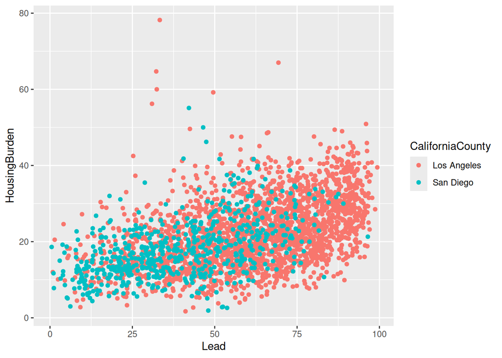

```r
ces_sub <-
  ces |>
  filter(CaliforniaCounty %in% c("Los Angeles", "San Diego"))

ggplot(ces_sub, aes(x = Lead, y = HousingBurden, color = CaliforniaCounty)) +
  geom_point()
```

# Part 2

### 2.1

Fit a linear regression model with `LowBirthWeight` as the outcome and `HousingBurden` as the predictor. Save the model fit in an object called “lmfit_bw” and display the summary table with `summary()`.

`HousingBurden`: Percentage of housing-burdened low-income households. Households are considered cost-burdened when they spend more than 30% of their income on rent, mortgage payments, and other housing costs

`LowBirthWeight`: Percentage of births that are low birth weight.

```
# General format
glm(y ~ x, data = DATASET_NAME)
```

```r
lmfit_bw <- glm(LowBirthWeight ~ HousingBurden, data = ces)
summary(lmfit_bw)
```

```
##
## Call:
## glm(formula = LowBirthWeight ~ HousingBurden, data = ces)
##
## Coefficients:
##               Estimate Std. Error t value Pr(>|t|)
## (Intercept)    3.98050    0.04277   93.06   <2e-16 ***
## HousingBurden  0.05542    0.00212   26.14   <2e-16 ***
## ---
## Signif. codes:  0 '***' 0.001 '**' 0.01 '*' 0.05 '.' 0.1 ' ' 1
##
## (Dispersion parameter for gaussian family taken to be 2.311994)
##
##     Null deviance: 19567  on 7781  degrees of freedom
## Residual deviance: 17987  on 7780  degrees of freedom
##   (253 observations deleted due to missingness)
## AIC: 28611
##
## Number of Fisher Scoring iterations: 2
```

### 2.2

Take your code from 2.1 and add `Traffic` as another predictor. Save the model fit in an object called “lmfit_bw2” and display the summary table.

`Traffic`: Measure of traffic density within 150 meters of the census tract boundary

```r
lmfit_bw2 <- glm(LowBirthWeight ~ HousingBurden + Traffic, data = ces)
summary(lmfit_bw2)
```

```
##
## Call:
## glm(formula = LowBirthWeight ~ HousingBurden + Traffic, data = ces)
##
## Coefficients:
##                Estimate Std. Error t value Pr(>|t|)
## (Intercept)   3.957e+00  4.541e-02  87.149   <2e-16 ***
## HousingBurden 5.503e-02  2.138e-03  25.742   <2e-16 ***
## Traffic       2.828e-05  1.754e-05   1.612    0.107
## ---
## Signif. codes:  0 '***' 0.001 '**' 0.01 '*' 0.05 '.' 0.1 ' ' 1
##
## (Dispersion parameter for gaussian family taken to be 2.310696)
##
##     Null deviance: 19506  on 7759  degrees of freedom
## Residual deviance: 17924  on 7757  degrees of freedom
##   (275 observations deleted due to missingness)
## AIC: 28526
##
## Number of Fisher Scoring iterations: 2
```

# Practice on Your Own!

### P.3

Take your code from 2.2 and add an interaction term. Save the model fit in an object called “lmfit_bw3” and display the summary table.

- To include the interaction, use `HousingBurden * Traffic` in the formula.
- Save the model fit in an object called “lmfit_bw3” and display the summary table with `summary()`.

```r
lmfit_bw3 <- glm(LowBirthWeight ~ HousingBurden * Traffic, data = ces)
summary(lmfit_bw3)
```

```
##
## Call:
## glm(formula = LowBirthWeight ~ HousingBurden * Traffic, data = ces)
##
## Coefficients:
##                         Estimate Std. Error t value Pr(>|t|)
## (Intercept)            3.882e+00  6.474e-02  59.953   <2e-16 ***
## HousingBurden          5.940e-02  3.429e-03  17.324   <2e-16 ***
## Traffic                9.475e-05  4.432e-05   2.138   0.0325 *
## HousingBurden:Traffic -3.695e-06  2.262e-06  -1.633   0.1025
## ---
## Signif. codes:  0 '***' 0.001 '**' 0.01 '*' 0.05 '.' 0.1 ' ' 1
##
## (Dispersion parameter for gaussian family taken to be 2.310199)
##
##     Null deviance: 19506  on 7759  degrees of freedom
## Residual deviance: 17918  on 7756  degrees of freedom
##   (275 observations deleted due to missingness)
## AIC: 28526
##
## Number of Fisher Scoring iterations: 2
```

### P.4

Let’s look at a different dataset. This data comes from a research article looking at how well internet searches predicted influenza infections. See the DaSEH website for a link to the paper.

`any.flu`: how many internet searches related to flu for a given survey respondent

`parent`: binary variable, is the respondent a parent (1) or not (0)

`household.flu`: binary variable, did someone in the household have a flu infection (1 = yes, 0 = no).

```r
flu <- read_csv("https://daseh.org/data/Wojcik_2021_flu.csv")
```

Fit a logistic regression model where:

- The outcome is `household.flu`.
- `any.flu` is the predictor.
- Use `glm` and family = binomial(link = “logit”).
- Save the model fit in an object called “logfit_flu” and display the summary table with `summary()`.
- Try adding `parent` as a predictor. What is the result?

```r
logfit_flu <-
  glm(
    household.flu ~ any.flu,
    data = flu,
    family = binomial(link = "logit")
  )
summary(logfit_flu)
```

```
##
## Call:
## glm(formula = household.flu ~ any.flu, family = binomial(link = "logit"),
##     data = flu)
##
## Coefficients:
##              Estimate Std. Error z value Pr(>|z|)
## (Intercept) -0.687308   0.088171  -7.795 6.43e-15 ***
## any.flu      0.017949   0.009576   1.874   0.0609 .
## ---
## Signif. codes:  0 '***' 0.001 '**' 0.01 '*' 0.05 '.' 0.1 ' ' 1
##
## (Dispersion parameter for binomial family taken to be 1)
##
##     Null deviance: 845.74  on 653  degrees of freedom
## Residual deviance: 840.81  on 652  degrees of freedom
## AIC: 844.81
##
## Number of Fisher Scoring iterations: 4
```

```r
logfit_flu2 <-
  glm(
    household.flu ~ any.flu + parent,
    data = flu,
    family = binomial(link = "logit")
  )
summary(logfit_flu2)
```

```
##
## Call:
## glm(formula = household.flu ~ any.flu + parent, family = binomial(link = "logit"),
##     data = flu)
##
## Coefficients:
##              Estimate Std. Error z value Pr(>|z|)
## (Intercept) -1.207431   0.115999 -10.409  < 2e-16 ***
## any.flu      0.019027   0.009475   2.008   0.0446 *
## parent       1.461327   0.179685   8.133  4.2e-16 ***
## ---
## Signif. codes:  0 '***' 0.001 '**' 0.01 '*' 0.05 '.' 0.1 ' ' 1
##
## (Dispersion parameter for binomial family taken to be 1)
##
##     Null deviance: 845.74  on 653  degrees of freedom
## Residual deviance: 772.03  on 651  degrees of freedom
## AIC: 778.03
##
## Number of Fisher Scoring iterations: 4
```